# Project 7

Git In

11/02/2021

### Introduction

Organismal biologists have a tendency to, in great error, forgo including phylogenetic structure in their research analyses (Freckleton, Harvey, and Pagel 2002). When discussing traits and how they vary in the context of another, it is important to include some phylogenetic data. Species cannot be considered to be statistically independent since they are interrelated in a structured phylogeny (Felsenstein 1985). This isn’t always possible depending on the availability of phylogenetic data, but with advances in evolutionary biology, this issue is becoming less prevalent. This study aims to assess the scaling relationship of maximum and minimum daily body temperature between human and 52 species of non-human mammals (Mortola and Lanthier 2004).Then, this relationship can be assessed in a phylogenetic context using phylogenetic least squares under Brownian and Ornstein-Uhlenbeck models. The phylogenetic signal is assessed using Pagel’s lamba, a way to measure how much correlations in traits reflect their shared evolutionary history (Pagel 2019).

### Methods

Data was collected from Mortola and Lanthier (Mortola and Lanthier 2004). To consider phylogeny, a trimmed down phylogenetic tree of the taxa included in the study was used (Upham, Esselstyn, and Jetz 2019). Log-log regression models were made to compare Tb values (T low, T high, and T delta) as a function of mass. We also reproduced the graphs from the (Mortola and Lanthier 2004) paper.

Secondly, to determine the phylogenetic signal of the four variables in the study, Pagel’s lambda analysis was used. Pagel’s lambda is a method that mutes phylogenetic signal by lengthening branch tips to determine how much of a trait is driven by phylogeny. A lambda value of zero means there is no phylogenetic signal and a lambda value of one means that the data conforms to a Brownian Motion Model.

After running the Pagel’s lambda analysis. Brownian Motion (BM) and Ornstein-Uhlenbeck (OU) models were run on T low, T high, and T delta to see which phylogenetically-informed model fit the data better. The OU models were better fits for each parameter. Therefore, the OU models were used in further tests. We created linear regressions for both the non-phylogentically-informed (NPI) and phylogenetically-informed (OU) models and calculated the estimated intercepts and slope coefficiencts (Tables 3&4).

### Results

We were able to reproduce the scaling relationships of Mortola and Lanthier (2004) for Tmin, Tmax, and T delta.

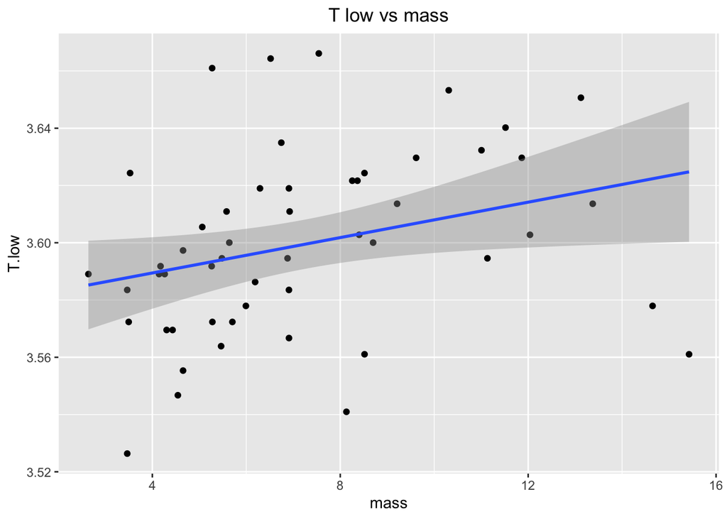

Figure 1: Graph of T low vs mass

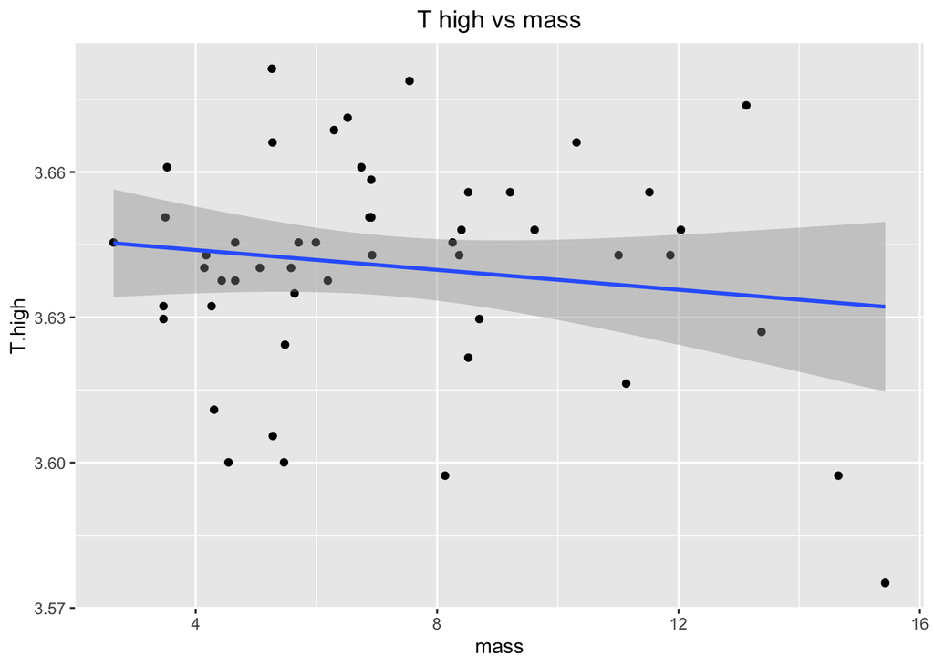

Figure 2: Graph of T high vs mass

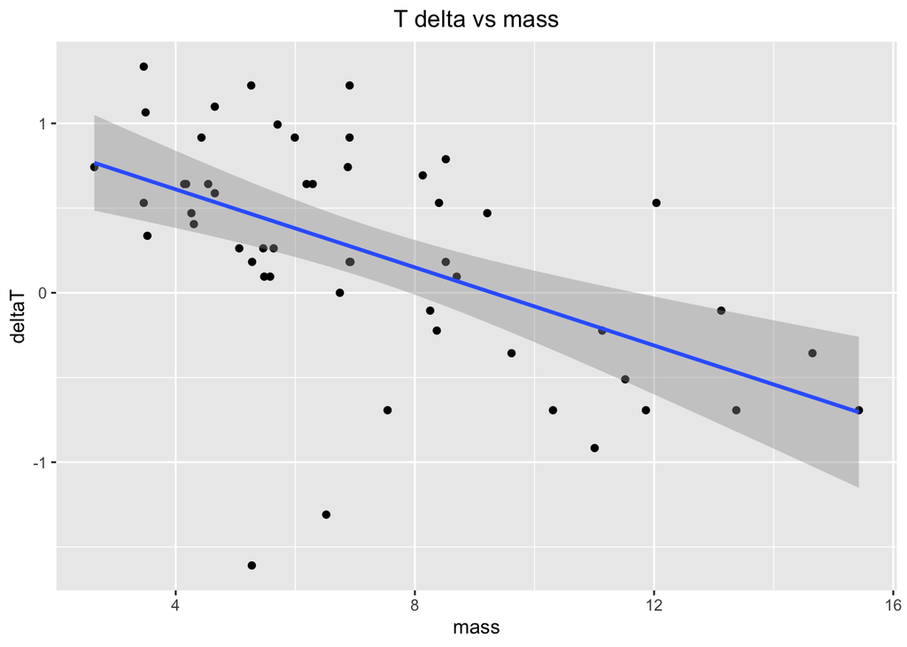

Figure 3: Graph of T delta vs mass

Significant phylogenetic signal was found for all traits by running Pagel’s Lambda and phylogenetic signal was high (close to 1).

Table 1: Pagel’s Lambda Values

| Variable | Lambda | P-value |
| --- | --- | --- |
| Mass | 0.9838295 | 0.0000000 |
| T high | 0.8730429 | 0.0354453 |
| T low | 0.7852911 | 0.0034621 |
| T delta | 0.7207558 | 0.0003959 |

AIC scores were lower for the OU model for every trait.

Table 2: AIC Scores of BM and OU Models

| fit | delta | w | Model |
| --- | --- | --- | --- |
| -201.2 | 43.56 | 3.054e-10 | T low BM |
| -209 | 35.77 | 1.503e-08 | T low OU |
| -240.8 | 3.985 | 0.12 | T high BM |
| -244.8 | 0 | 0.88 | T high OU |
| 104.1 | 348.9 | 1.543e-76 | T delta BM |
| 90.91 | 335.7 | 1.12e-73 | T delta OU |

Table 3: Intercept data for NPI vs OU models

[output not shown]

The table below summarizes the slope coefficient data from the non-phylogentically-informed (NPI) and phylogenetically-informed (OU) models. The values for slope coefficient were different in the NPI and OU model for all three variables and for T low, the phylogenetically-informed model showed no significance where the NPI model showed significance. In other words, when you consider phylogeny, the significant correlation between T low and mass that Mortola and Lanthier found does not exist.

Table 4: Slope Coefficients for NPI vs OU Models

| Variable | Model | Slope | P-value | Signficant |
| --- | --- | --- | --- | --- |
| T low | NPI | 0.0030913 | 0.0308360 | Yes |
| T low | OU | 0.0028319 | 0.0854414 | No |
| T high | NPI | -0.0010265 | 0.3088591 | No |
| T high | OU | -0.0015287 | 0.2255076 | No |
| T delta | NPI | -0.1151818 | 0.0000360 | Yes |
| T delta | OU | -0.1129457 | 0.0001710 | Yes |

## References

Felsenstein, Joseph. 1985. “Phylogenies and the Comparative Method.” *The American Naturalist* 125 (1): 1–15. http://www.jstor.org/stable/2461605.

Freckleton, R. P., P. H. Harvey, and M Pagel. 2002. “Phylogenetic Analysis and Comparative Data: A Test and Review of Evidence.” *The American Naturalist* 160 (6): 712–26.

Mortola, Jacopo, and Clement Lanthier. 2004. “Scaling the Amplitudes of the Circadian Pattern of Resting Oxygen Consumption, Body Temperature and Heart Rate in Mammals.” *Comparative Biochemistry and Physiology* 139 (1): 83–95.

Pagel, M. 2019. “Inferring the Historical Patterns of Biological Evolution.” *Nature* 401: 877–84.

Upham, Nathan, Jacob Esselstyn, and Walter Jetz. 2019. “Inferring the Mammal Tree: Species-Level Sets of Phylogenies for Questions in Ecology, Evolution, and Conservation.” *PLOS Biology* 17 (12).